# The female rivalry hypothesis - Sensitivity Analyses 2

Scott Claessens

2020-12-01

```r
library(tidyverse)
library(cowplot)
library(lme4)
library(lmerTest)
```

For further sensitivity analyses, we fixed the conditions of the agent-based model to those in Experiment 3, and manipulated one parameter at a time to see how sensitive our main result was to model variations.

# 1. Offspring investment

First, we manipulate the number of “offspring investment” units required to successfully have a child. Load in the data.

```r
d <-
  read.csv('data/v6/cleanData/ovulationSensitivity2_OffspringInvest.csv') %>%
  as_tibble() %>%
  mutate(Run      = factor(Run),
         Sens     = factor(Sens),
         Strategy = factor(Strategy))
```

## 1.1. Analyses

We run mixed ANOVAs to determine (a) the main effect of the required offspring investment (‘Sens’), (b) the main effect of Strategy, and (c) the interaction between these. Our first ANOVA includes lifetime reproductive success as the dependent variable.

```r
m1.1 <- aov(RS ~ Sens*Strategy + Error(Run/Strategy), data = d)

summary(m1.1)
```

```
##
## Error: Run
##            Df Sum Sq Mean Sq F value Pr(>F)
## Sens        5  44.28   8.856   21.11 <2e-16 ***
## Residuals 594 249.16   0.419
## ---
## Signif. codes:  0 '***' 0.001 '**' 0.01 '*' 0.05 '.' 0.1 ' ' 1
##
## Error: Run:Strategy
##                Df Sum Sq Mean Sq F value  Pr(>F)
## Strategy        1 221.79  221.79 3628.96 < 2e-16 ***
## Sens:Strategy   5   4.99    1.00   16.33 4.1e-15 ***
## Residuals     594  36.30    0.06
## ---
## Signif. codes:  0 '***' 0.001 '**' 0.01 '*' 0.05 '.' 0.1 ' ' 1
```

```r
model.tables(m1.1, "means")
```

```
## Tables of means
## Grand mean
##
## 6.833158
##
##  Sens
## Sens
##   100   200   300   400   500   600
## 6.419 6.847 6.941 6.952 6.852 6.987
##
##  Strategy
## Strategy
## Concealers  Revealers
##      7.263      6.403
##
##  Sens:Strategy
##      Strategy
## Sens  Concealers Revealers
##   100 6.979      5.859
##   200 7.306      6.388
##   300 7.328      6.554
##   400 7.344      6.561
##   500 7.263      6.441
##   600 7.357      6.617
```

Let’s run the same model with paternal investment as the dependent variable.

```r
m1.2 <- aov(PI ~ Sens*Strategy + Error(Run/Strategy), data = d)

summary(m1.2)
```

```
##
## Error: Run
##            Df    Sum Sq Mean Sq F value  Pr(>F)
## Sens        5  22251164 4450233     3.8 0.00214 **
## Residuals 594 695621698 1171080
## ---
## Signif. codes:  0 '***' 0.001 '**' 0.01 '*' 0.05 '.' 0.1 ' ' 1
##
## Error: Run:Strategy
##                Df    Sum Sq   Mean Sq  F value  Pr(>F)
## Strategy        1 1.263e+09 1.263e+09 2967.178 < 2e-16 ***
## Sens:Strategy   5 6.784e+06 1.357e+06    3.187 0.00755 **
## Residuals     594 2.529e+08 4.257e+05
## ---
## Signif. codes:  0 '***' 0.001 '**' 0.01 '*' 0.05 '.' 0.1 ' ' 1
```

```r
model.tables(m1.2, "means")
```

```
## Tables of means
## Grand mean
##
## 6244.507
##
##  Sens
## Sens
##  100  200  300  400  500  600
## 6370 6406 6301 6194 5996 6201
##
##  Strategy
## Strategy
## Concealers  Revealers
##       7270       5219
##
##  Sens:Strategy
##      Strategy
## Sens  Concealers Revealers
##   100 7482       5258
##   200 7382       5430
##   300 7218       5384
##   400 7177       5211
##   500 7122       4870
##   600 7242       5159
```

## 1.2. Visualisation

We now visualise the interaction between required offspring investment and female strategy with two line graphs, one for each dependent variable. Again, the code for this plot is hidden (see the source .Rmd code for details).

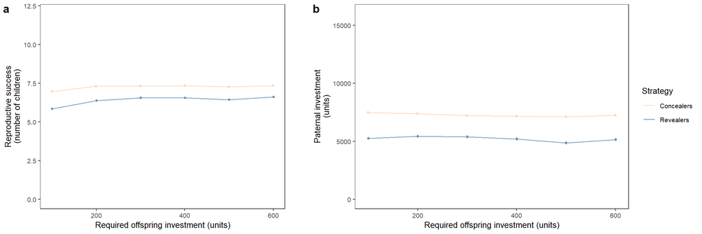